# Applied Network Analysis Assignment 2

Maren Rieker

2023-04-19

For this assignment, I am using a data set containing interactions between characters in the TV show [*Breaking Bad*](https://figshare.com/articles/dataset/TV_Series_Networks_of_characters/2199646/11?file=7353802). It contains a static, cumulative conversational network with interactions from all episodes of seasons 1 and 2. In order to make sense of some results and contextualise them with the plot, I have consulted the [Fandom wiki](https://breakingbad.fandom.com/wiki/Breaking_Bad_Wiki) of the show.

```r
network_bb <- read_graph("BB_cum.graphml", format = "graphml")
```

### Getting to know the data

What are even the vertices & edges now?

```r
V(network_bb)$label
```

```
##   [1] "ABQ Dectective #1"                "ABQ Dectective #2"
##   [3] "George Merkert"                   "Hank Schrader"
##   [5] "Union Rep"                        "APD Officer"
##   [7] "Walter White"                     "Adam Pinkman"
##   [9] "Jake Pinkman"                     "Jesse Pinkman"
##  [11] "Mr. Gardiner"                     "Mrs. Pinkman"
##  [13] "Saul Goodman"                     "Addict"
##  [15] "Tattooed Biker"                   "Agent Buddy"
##  [17] "Andrea Cantillo"                  "Brock Cantillo"
##  [19] "Group Leader"                     "Mrs. Cantillo"
##  [21] "Skinny Pete"                      "Andrew Coffman"
##  [23] "Antonio"                          "Arms Dealer"
##  [25] "Leonel Salamanca"                 "Marco Salamanca"
##  [27] "Arroyo Realty Manager"            "Badger"
##  [29] "Christian \"Combo\" Ortega"       "Clovis"
```

[output cut: 69 more lines]

```r
V(network_bb)$name
```

```r
E(network_bb)$weight
```

```
##   [1]    5.040    6.462   55.777   13.700    6.930    8.260    1.400    9.920
##   [9]  125.836   18.310   73.900   48.670   28.340    2.250   15.810   53.074
##  [17]  324.766   18.289    3.964    1.880    0.780   31.329   18.698   67.240
##  [25]   46.840   10.080   21.940  172.923   32.950   18.029  553.824  116.469
##  [33]  114.719   16.260   29.960   76.380   85.520    6.828    2.200    2.802
##  [41]   16.000    7.330    2.920    8.960    4.760   24.530   29.040   19.826
##  [49]   33.019  124.303   75.417   32.480   24.040    9.240    6.040   48.196
##  [57]   21.560  383.901    3.651   12.143    9.800  180.020   49.471    3.290
##  [65]   37.892  157.941   37.079    6.080   38.720   13.560   36.640   12.754
##  [73]   18.970   63.330    1.450   54.963   26.640   52.287    0.880   77.183
##  [81]    8.335   34.400   24.400    2.800   80.040  334.000  199.716    9.893
##  [89]   10.330   36.320    2.250   22.604    1.450  152.173   97.260   36.940
##  [97]   28.120    1.240    8.210  126.744  199.353    3.969    1.800   27.630
## [105]   35.799   52.271   44.197   11.400   14.140    1.520    3.760   23.400
## [113]  190.679    2.400    7.800   25.280    4.920   45.000   27.910    1.560
```

[output cut: 24 more lines]

```r
#network_bb[]
edge_attr_names(network_bb)
```

```
## [1] "weight"
```

```r
edge_attr(network_bb)
```

```
## $weight
##   [1]    5.040    6.462   55.777   13.700    6.930    8.260    1.400    9.920
##   [9]  125.836   18.310   73.900   48.670   28.340    2.250   15.810   53.074
##  [17]  324.766   18.289    3.964    1.880    0.780   31.329   18.698   67.240
##  [25]   46.840   10.080   21.940  172.923   32.950   18.029  553.824  116.469
##  [33]  114.719   16.260   29.960   76.380   85.520    6.828    2.200    2.802
##  [41]   16.000    7.330    2.920    8.960    4.760   24.530   29.040   19.826
##  [49]   33.019  124.303   75.417   32.480   24.040    9.240    6.040   48.196
##  [57]   21.560  383.901    3.651   12.143    9.800  180.020   49.471    3.290
##  [65]   37.892  157.941   37.079    6.080   38.720   13.560   36.640   12.754
##  [73]   18.970   63.330    1.450   54.963   26.640   52.287    0.880   77.183
##  [81]    8.335   34.400   24.400    2.800   80.040  334.000  199.716    9.893
##  [89]   10.330   36.320    2.250   22.604    1.450  152.173   97.260   36.940
##  [97]   28.120    1.240    8.210  126.744  199.353    3.969    1.800   27.630
## [105]   35.799   52.271   44.197   11.400   14.140    1.520    3.760   23.400
```

[output cut: 25 more lines]

```r
vertex_attr(network_bb)
```

```
## $label
##   [1] "ABQ Dectective #1"                "ABQ Dectective #2"
##   [3] "George Merkert"                   "Hank Schrader"
##   [5] "Union Rep"                        "APD Officer"
##   [7] "Walter White"                     "Adam Pinkman"
##   [9] "Jake Pinkman"                     "Jesse Pinkman"
##  [11] "Mr. Gardiner"                     "Mrs. Pinkman"
##  [13] "Saul Goodman"                     "Addict"
##  [15] "Tattooed Biker"                   "Agent Buddy"
##  [17] "Andrea Cantillo"                  "Brock Cantillo"
##  [19] "Group Leader"                     "Mrs. Cantillo"
##  [21] "Skinny Pete"                      "Andrew Coffman"
##  [23] "Antonio"                          "Arms Dealer"
##  [25] "Leonel Salamanca"                 "Marco Salamanca"
##  [27] "Arroyo Realty Manager"            "Badger"
```

[output cut: 89 more lines]

## Network Properties

Size of the network can be identified via its diameter.

```r
diameter(network_bb, directed = FALSE, weights = NA)
```

```
## [1] 7
```

```r
get_diameter(network_bb, directed = FALSE, weights = NA)
```

```
## + 8/167 vertices, from 2164c8c:
## [1] 26 24 25 59  4 33 48 57
```

The longest path between two nodes in the network is seven edges long and goes from Marco Salamanca, a cartel hitman, through an arms dealer to his cousin Leonel, to meth mastermind Gustavo Fring, to DEA agent Hank Schrader, Carmen Molina, a concerned parent to Police Officer #1.

Next, I will determine the mean distance between two nodes.

```r
mean_distance(network_bb, directed = FALSE, weights = NA)
```

```
## [1] 2.797647
```

```r
distances <- distances(network_bb, weights = NA)
distances[1:10, 1:10]
```

```
##       [,1] [,2] [,3] [,4] [,5] [,6] [,7] [,8] [,9] [,10]
##  [1,]    0    1    1    1    1    3    2    3    3     2
##  [2,]    1    0    2    1    1    3    2    3    3     2
##  [3,]    1    2    0    1    2    2    1    3    3     2
##  [4,]    1    1    1    0    1    2    1    2    2     1
##  [5,]    1    1    2    1    0    3    2    3    3     2
##  [6,]    3    3    2    2    3    0    1    3    3     2
##  [7,]    2    2    1    1    2    1    0    2    2     1
##  [8,]    3    3    3    2    3    3    2    0    1     1
##  [9,]    3    3    3    2    3    3    2    1    0     1
## [10,]    2    2    2    1    2    2    1    1    1     0
```

Edge density is calculated by dividing the number of links by the number of all possible links.

```r
edge_density(network_bb)
```

```
## [1] 0.02207633
```

```r
#test if the graph is not a multigraph because then the edge density would be useless
is_simple(network_bb)
```

```
## [1] TRUE
```

The network is quite sparse, considering that the density can be between 0 and 1.

```r
#get.adjacency(network_bb)
```

To get a first impression of the network, a plot.

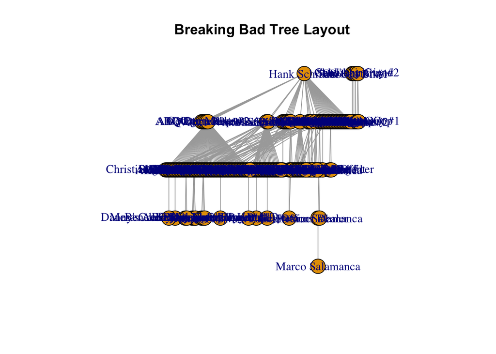

```r
layout_tree <- layout_as_tree(network_bb)#,
                             # root = "Walter White")

plot(network_bb,
     layout = layout_tree,
     main = "Breaking Bad Tree Layout")
```

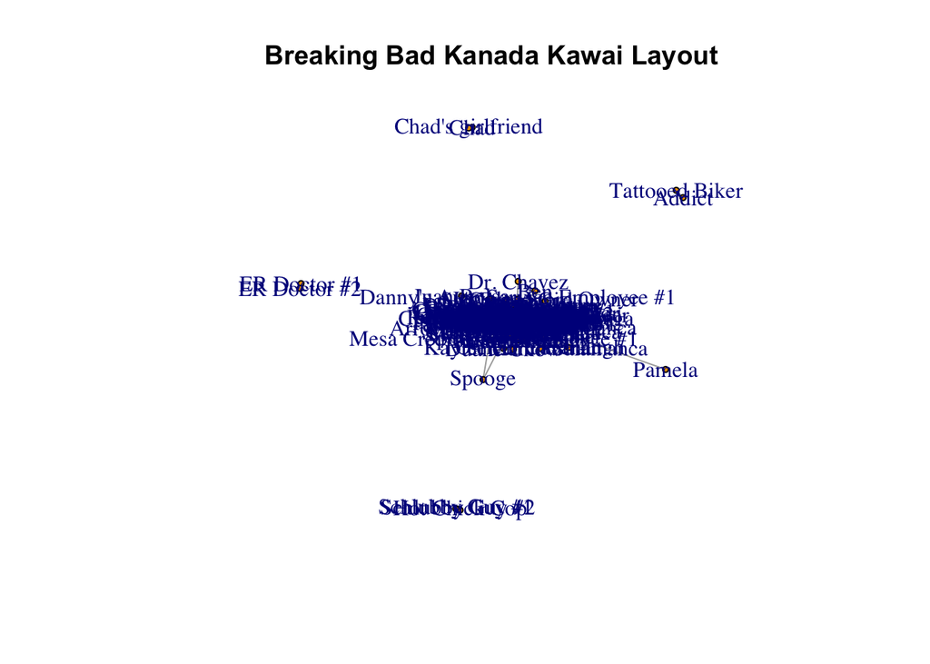

```r
plot(network_bb,
     layout = layout_with_kk,
     vertex.size = 3,
     main = "Breaking Bad Kanada Kawai Layout")
```

A more informative and visually more appealing plot of the network can be found [here](https://figshare.com/articles/dataset/TV_Series_Networks_of_characters/2199646/11?file=4128649).

## Degree Distribution and Centralities

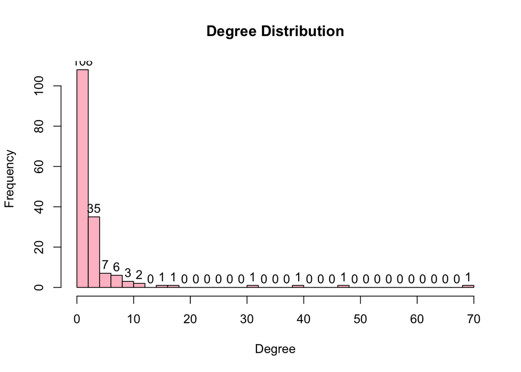

```r
#plot degree distribution
degree_bb <- degree(network_bb)
degree_hist <- hist(degree_bb,
                    main = "Degree Distribution",
                    xlab = "Degree",
                    breaks = 30,
                    col = "pink")
text(degree_hist$mids, degree_hist$counts, labels = degree_hist$counts, adj = c(0.5, -0.5))
```

As the network data is undirected, I can not distinguish between in- and out degree. The distribution clearly follows the power law, as is to be expected in the analysis of interactions in a TV show with a few main characters. It can be assumed that these main characters are the hubs.I would set the treshold ok k = 30 to classify a person as a hub, therefore there are four in the data set.

Now, I want to see which characters have the most connections to other people, so I’ll have a look at the degrees of the nodes. First, I check the degree of some main characters that came to mind.

```r
#the data only contains labels which identify the persons, but the degree function needs the attribute "name" to look up specific people
vertex_attr(network_bb, "name") <- V(network_bb)$label

#there we go
degree(network_bb, v = c("Walter White", "Skyler White", "Jesse Pinkman", "Saul Goodman", "Ted Beneke", "Gustavo Fring", "Hank Schrader", "Marie Schrader", "Mike Ehrmantraut", "Walter White Jr."))
```

```
##     Walter White     Skyler White    Jesse Pinkman     Saul Goodman
##               69               32               47               12
##       Ted Beneke    Gustavo Fring    Hank Schrader   Marie Schrader
##                5               10               39               16
## Mike Ehrmantraut Walter White Jr.
##                8               18
```

The degrees of the respective characters are in line with my expectation. In the further analysis, I will keep a closer eye on the connections of Ted (Skyler’s boss and affair partner in season 3 - unfortunately not covered in this data set), Mike (the fixer), and Walter White Jr. (the 15 year old son of Skyler and Walter). I think these characters are interesting from a storyline standpoint, as Ted is not in the drug business, Mike is crucial to the drug storyline but not involved with the main characters on a private level, and having a closer look at Walter Junior’s relationships might give an indication how well Walter White managed to keep his worlds separate from each other in the beginning of the show.

But first, a look at different centrality measures with a focus on direct connections between nodes: * Degree (how many connections one node has) * Closeness (the distance between a node and all other nodes) * Betweenness (how many short connection a node has, which indicates information flows in social networks)

```r
#degree, sorted from highest to lowest
sort(degree(network_bb), decreasing = TRUE)
```

```
##                     Walter White                    Jesse Pinkman
##                               69                               47
##                    Hank Schrader                     Skyler White
##                               39                               32
##                 Walter White Jr.                   Marie Schrader
##                               18                               16
##                     Saul Goodman                     Steven Gomez
##                               12                               12
##                    Carmen Molina                    Gustavo Fring
##                               10                               10
##                           Badger                   George Merkert
##                                9                                8
##                  Donald Margolis                 Mike Ehrmantraut
##                                8                                8
##                      Skinny Pete                    Dr. Delcavoli
##                                7                                7
##                   Tuco Salamanca                     Mrs. Pinkman
##                                7                                6
##                     Adam Pinkman                  Andrea Cantillo
##                                5                                5
##         Christian "Combo" Ortega                             Getz
##                                5                                5
##                       Ted Beneke                Gretchen Schwartz
##                                5                                5
##                ABQ Dectective #1                     Mr. Gardiner
##                                4                                4
##                     Group Leader                          Tortuga
##                                4                                4
##                  DEA agent Vanco                        Doctor #1
##                                4                                4
##                    Jane Margolis                 Elliott Schwartz
##                                4                                4
##                ABQ Dectective #2                        Union Rep
##                                3                                3
##                     Jake Pinkman                 Leonel Salamanca
##                                3                                3
##                           Clovis                            Billy
##                                3                                3
##              Concerned Parent #1              Concerned Parent #2
##                                3                                3
```

[output cut: 113 more lines]

```
##                                1                                1
##                Officer Cavanaugh                           Pamela
##                                1                                1
##                   Pollos Manager                      Prisoner #1
##                                1                                1
##                          Realtor                  Receptionist #1
##                                1                                1
##           Restaurant Employee #1                  Schlubby Guy #1
##                                1                                1
##                      Waitress #1                       Student #1
##                                1                                1
##                       Technician                       Thug Buddy
##                                1                                1
##                       Urinal Guy
##                                1
```

```r
#closeness, sorted from highest to lowest
sort(closeness(network_bb), decreasing = TRUE)
```

```
##                             Chad                Chad's girlfriend
##                     1.020408e-01                     1.020408e-01
##                  Schlubby Guy #2                     ER Doctor #1
##                     7.867821e-02                     7.072136e-02
##                     ER Doctor #2                  Schlubby Guy #1
##                     7.072136e-02                     5.249344e-02
##                    Hot Chick Cop                           Addict
##                     5.241090e-02                     3.528582e-02
##                   Tattooed Biker                 Walter White Jr.
##                     3.528582e-02                     1.943705e-04
##                     Walter White                         Nurse #2
##                     1.942017e-04                     1.921475e-04
##                    Jesse Pinkman                      Tim Roberts
##                     1.916127e-04                     1.906704e-04
##               Physical Therapist                          No-Doze
##                     1.902347e-04                     1.896063e-04
##                     Steven Gomez                            Billy
##                     1.892167e-04                     1.885398e-04
##                    Dr. Delcavoli                        Scientist
##                     1.878675e-04                     1.876424e-04
##                      APD Officer                 Jock's Friend #1
##                     1.863001e-04                     1.853032e-04
##                        Mrs. Pope                           Ob-Gyn
##                     1.851628e-04                     1.850096e-04
##                          Jeffrey                            Jimmy
##                     1.848691e-04                     1.847963e-04
##           Restaurant Employee #1               Medical Technician
##                     1.843180e-04                     1.841592e-04
##                    Emilio Koyama                        Francesca
##                     1.835583e-04                     1.834949e-04
##                            Ricky                             Jock
##                     1.833710e-04                     1.813829e-04
##                        Pa Kettie                      Tio's nurse
##                     1.804353e-04                     1.798255e-04
##                             Getz                    Hank Schrader
##                     1.797376e-04                     1.784712e-04
##                    Carmen Molina                      Prisoner #1
##                     1.779930e-04                     1.778756e-04
##         Christian "Combo" Ortega                   George Merkert
##                     1.772175e-04                     1.770098e-04
```

[output cut: 113 more lines]

```
##                     6.154873e-05                     6.135640e-05
##                       Duane Chow                             Cara
##                     6.039532e-05                     5.887924e-05
##                      Arms Dealer              Jewelry Store Owner
##                     5.748030e-05                     5.553439e-05
##                              Ben                Officer Cavanaugh
##                     5.408210e-05                     5.106706e-05
##                 Hector Salamanca                       Dr. Chavez
##                     4.967780e-05                     4.920813e-05
##                            Wendy                       Juan Bolsa
##                     4.606340e-05                     3.732330e-05
##                  Marco Salamanca                           Spooge
##                     3.585938e-05                     3.089120e-05
##                           Pamela
##                     1.439144e-05
```

```r
#betweenness, sorted from highest to lowest
sort(betweenness(network_bb), decreasing = TRUE)
```

```
##                     Walter White                    Jesse Pinkman
##                             7138                             4796
##                 Walter White Jr.                         Nurse #2
##                             4473                             3174
##                     Skyler White                 Jock's Friend #1
##                             2746                             2674
##                             Jock                    Hank Schrader
##                             2566                             2493
##                     Steven Gomez                            Billy
##                             2257                             2051
##                        Pa Kettie                    Dr. Delcavoli
##                             1253                             1242
##                    Carmen Molina                      Tio's nurse
##                             1206                              894
##                    Gustavo Fring                   Tuco Salamanca
##                              764                              626
##                  Donald Margolis                           Victor
##                              617                              612
##                        Francesca                   Marie Schrader
##                              604                              565
##                      Skinny Pete                 Mike Ehrmantraut
##                              481                              465
##                 Leonel Salamanca                     Saul Goodman
##                              464                              460
##         Christian "Combo" Ortega                        Scientist
##                              416                              410
##                   George Merkert                          Tortuga
##                              387                              311
##              Concerned Parent #2                              Ken
##                              311                              311
##               Beneke Employee #2                       Sara Tyree
##                              310                              310
##                        SAC Ramey                  Andrea Cantillo
##                              304                              179
##                   Andrew Coffman                     Mrs. Pinkman
##                              166                              159
##                  DEA agent Vanco                      Arms Dealer
##                              159                              156
##                           Badger                       Ted Beneke
##                              156                              156
```

[output cut: 113 more lines]

```
##                                0                                0
##                           Pamela                   Pollos Manager
##                                0                                0
##                      Prisoner #1                          Realtor
##                                0                                0
##                  Receptionist #1           Restaurant Employee #1
##                                0                                0
##                  Schlubby Guy #1                             Stan
##                                0                                0
##                      Waitress #1                       Student #1
##                                0                                0
##                       Technician                       Thug Buddy
##                                0                                0
##                       Urinal Guy
##                                0
```

The *degree* shows that Walter White has the most direct connections to other characters, followed by Jesse Pinkman and Hank Schrader. In the top 10 of the degree, there are two DEA officers, Hank Schrader and Steven Gomez. A surprise to me was that Carmen Molina (a character I personally did not remember, she’s working at the high school where Walter teaches chemistry and which is attended by Walter Jr.) is in there and has the same degree as Gustavo Frings.

The *closeness* measure can be interpreted as the number of steps required to reach every node starting at a certain node. A higher value here means less centrality, which in the context of a social network means that information takes longer to reach the people with higher centrality values. The sort function did not work correctly in this case, but it can be seen that Jesse’s closeness value is a bit lower than Walter’s, and Hank’s is lower than both.

*Betweenness* helps to identify “vulnerable” points in a network, as it shows the shortest paths through one node in relation to all shortest paths in the network. If much information goes through a node, cutting it out of the network would disturb the flow of information considerably. For the Breaking Bad network, it is interesting (and actually a bit suspicious) that “Nurse #2”, someone called Jock and his friend seem to have some of the highest betweenness centralities, as they are not important characters at all. Values are very unequally distributed, with most characters having a betweenness centrality of zero and the top 13 one in the four digits with Walter White topping the list at 7138.

There are also centrality measures that focus on the entire network structure: * Eigenvector (takes the importance of the nodes a given node is connected to into account) * Katz (not available for igraph, but this measure could provide very interesting insights into the social dynamics of the show, as it considers the proximity of neighbourhoods) * PageRank (shows the centrality of a node by simulating a random walker along the network - the higher the probability of the random walker is to appear on a node, the more central it is)

```r
#eigenvector centrality, sorted from highest to lowest
sort(eigen_centrality(network_bb)$vector, decreasing = TRUE)
```

```
##                     Walter White                    Jesse Pinkman
##                     1.000000e+00                     8.585612e-01
##                     Skyler White                     Saul Goodman
##                     4.721623e-01                     2.304723e-01
##                    Hank Schrader                 Walter White Jr.
##                     1.619384e-01                     1.536843e-01
##                    Gustavo Fring                   Marie Schrader
##                     1.160198e-01                     1.143901e-01
##                    Jane Margolis                 Mike Ehrmantraut
##                     1.129109e-01                     6.129697e-02
##                           Badger                  Gale Boetticher
##                     5.873994e-02                     5.709147e-02
##                   Tuco Salamanca                Gretchen Schwartz
##                     5.413718e-02                     5.225633e-02
##                       Ted Beneke                      Skinny Pete
##                     4.847510e-02                     4.574877e-02
##                   Domingo Molina                    Carmen Molina
##                     4.470954e-02                     4.408836e-02
##                     Group Leader                     Steven Gomez
##                     3.446524e-02                     3.232645e-02
##                  Andrea Cantillo                    Dr. Delcavoli
##                     3.118435e-02                     2.960328e-02
##                 Elliott Schwartz                           Pamela
##                     2.240433e-02                     2.128579e-02
##                  Donald Margolis                           Clovis
##                     2.034414e-02                     1.931382e-02
##         Christian "Combo" Ortega                           Spooge
##                     1.784111e-02                     1.676281e-02
##                     Mrs. Pinkman                            Wendy
##                     1.653709e-02                     1.602867e-02
##                     Adam Pinkman                       Dr. Chavez
##                     1.339078e-02                     1.079764e-02
##                Officer Cavanaugh                              Ben
##                     1.027119e-02                     9.494282e-03
##                   George Merkert                             Cara
##                     9.463058e-03                     9.423179e-03
##                            Barry                   Officer Saxton
##                     8.626218e-03                     8.124893e-03
##              Dr. Victor Bravenec                    Spooge's Lady
##                     7.800974e-03                     7.075902e-03
```

[output cut: 113 more lines]

```
##                     1.540448e-06                     1.430696e-06
##                       Thug Buddy                Police Officer #1
##                     9.724541e-07                     8.610403e-07
##             Prospective Buyer #1                  Marco Salamanca
##                     8.539984e-07                     1.149924e-08
##                    Hot Chick Cop                           Addict
##                     3.960779e-20                     0.000000e+00
##                   Tattooed Biker                             Chad
##                     0.000000e+00                     0.000000e+00
##                Chad's girlfriend                     ER Doctor #1
##                     0.000000e+00                     0.000000e+00
##                     ER Doctor #2                  Schlubby Guy #2
##                     0.000000e+00                     0.000000e+00
##                  Schlubby Guy #1
##                     0.000000e+00
```

```r
#pagerank, sorted from highest to lowest
sort(page_rank(network_bb)$vector, decreasing = TRUE)
```

```
##                     Walter White                    Jesse Pinkman
##                     0.2081246362                     0.1278948586
##                     Skyler White                    Hank Schrader
##                     0.0829313222                     0.0650048988
##                   Marie Schrader                     Saul Goodman
##                     0.0304188162                     0.0261621759
##                 Walter White Jr.                    Gustavo Fring
##                     0.0234539361                     0.0189050118
##                     Steven Gomez                    Jane Margolis
##                     0.0172076133                     0.0144562390
##                           Badger                 Mike Ehrmantraut
##                     0.0104776970                     0.0104181615
##                       Ted Beneke                    Carmen Molina
##                     0.0099215884                     0.0090728618
##                  Schlubby Guy #2                  Donald Margolis
##                     0.0087392782                     0.0078712280
##                   Tuco Salamanca                  Gale Boetticher
##                     0.0077175874                     0.0067517329
##                      Skinny Pete                           Addict
##                     0.0066618560                     0.0059880240
##                             Chad                     ER Doctor #1
##                     0.0059880240                     0.0059880240
##                   Tattooed Biker                Chad's girlfriend
##                     0.0059880240                     0.0059880240
##                     ER Doctor #2                Gretchen Schwartz
##                     0.0059880240                     0.0058137490
##                              Ken                  Andrea Cantillo
##                     0.0058036937                     0.0055030957
##                   George Merkert                      Arms Dealer
##                     0.0052726181                     0.0051654747
##                       Juan Bolsa                          Tortuga
##                     0.0051625609                     0.0049021428
##                     Group Leader                     Mrs. Pinkman
##                     0.0048532509                     0.0048019413
##                   Domingo Molina                    Dr. Delcavoli
##                     0.0046890382                     0.0046375309
##                    Hot Chick Cop                  Schlubby Guy #1
##                     0.0046211636                     0.0046036300
##                           Pamela                  Marco Salamanca
##                     0.0043360201                     0.0043335586
```

[output cut: 113 more lines]

```
##                     0.0009605795                     0.0009542827
##                        Pa Kettie               Beneke Employee #2
##                     0.0009483235                     0.0009424260
##                            Nurse                   Andrew Coffman
##                     0.0009302327                     0.0009298537
##               Stacey Ehrmantraut                      Agent Buddy
##                     0.0009290869                     0.0009216913
##                      Prisoner #1                      Waitress #2
##                     0.0009214453                     0.0009205189
##              Neighborhood Kid #1               Medical Technician
##                     0.0009190552                     0.0009139556
##                          Jeffrey           Restaurant Employee #1
##                     0.0009139276                     0.0009136931
##                      APD Officer
##                     0.0009104552
```

# Clusters and Communities

```r
components(network_bb)$no
```

```
## [1] 5
```

```r
components(network_bb)$csize
```

```
## [1] 158   2   2   2   3
```

The network consists of five different components, where each component consists of nodes which are connected to each other, but not to any other nodes. As is shown by their size, they are very unevenly sized with one component containing almost all nodes (it can be assumed that the storyline happens between the characters here). The other components only consist of 2 or 3 nodes, implying that these are probably interactions between characters that are not part of the plot, as they do not interact with the persons the show is about.

I will exclude these components for the following analysis.

```r
main_bb <- decompose(network_bb, min.vertices = 5)
```

Now, I will apply different algorithms to detect communities within the network that contains the characters which are important to the story.